# Estimating the conditional variance by local linear regression

Adrià Casanova, Silvia Ferrer, Matteo Mazzini

2024-11-25

```r
library(sm)
library(latex2exp)
```

# Aircraft Data

```r
data(aircraft)
#help(aircraft)
attach(aircraft)
lgPower <- log(Power)
lgSpan <- log(Span)
lgLength <- log(Length)
lgWeight <- log(Weight)
lgSpeed <- log(Speed)
lgRange <- log(Range)
```

# Estimating the conditional variance

## Using loc.pol.reg to fit nonparametric regressions

```r
source("locpolreg.R")

h.cv.gcv <- function(x,y,h.v = exp(seq(log(diff(range(x))/20),
                                       log(diff(range(x))/4),l=10)),
                     p=1,type.kernel="normal"){
  n <- length(x)
  cv <- h.v*0
  gcv <- h.v*0
  for (i in (1:length(h.v))){
    h <- h.v[i]
    aux <- locpolreg(x=x,y=y,h=h,p=p,tg=x,
                     type.kernel=type.kernel, doing.plot=FALSE)
    S <- aux$S
    h.y <- aux$mtgr
    hii <- diag(S)
    av.hii <- mean(hii)
    cv[i] <- sum(((y-h.y)/(1-hii))^2)/n
    gcv[i] <- sum(((y-h.y)/(1-av.hii))^2)/n
  }
  return(list(h.v=h.v,cv=cv,gcv=gcv))
}
```

We first fit a nonparametric regression to lgWeight against Yr.

```r
y <- lgWeight
x <- Yr
m.h.cv.gcv <- h.cv.gcv(x,y)
m.h.min.cv <- m.h.cv.gcv$h.v[which.min(m.h.cv.gcv$cv)]
m.h.min.gcv <- m.h.cv.gcv$h.v[which.min(m.h.cv.gcv$gcv)]
m.h.min.cv; m.h.min.gcv; m.h.min.cv == m.h.min.gcv
```

```
## [1] 4.185346
```

```
## [1] 4.185346
```

```
## [1] TRUE
```

By LOOCV and by Generalized LOOCV we obtain the same best bandwidth to estimate m(x).

```r
m.1 <- locpolreg(x, y, h=m.h.min.cv)$mtgr
```

Now, with the errors ($\epsilon$) of the previous regression, we are able to fit a nonparametric regression to $log(\epsilon^2)$ given Yr to estimate $log(\sigma^2(x))$, where $\sigma^2(x)$ is an estimate of the conditional variance of lgWeight given Yr.

```r
e.1 <- y - m.1
z.1 <- log(e.1^2)
q.h.cv.gcv <- h.cv.gcv(x,z.1)
q.h.min.cv <- q.h.cv.gcv$h.v[which.min(q.h.cv.gcv$cv)]
q.h.min.gcv <- q.h.cv.gcv$h.v[which.min(q.h.cv.gcv$gcv)]
q.h.min.cv; q.h.min.gcv; q.h.min.cv == q.h.min.gcv
```

```
## [1] 5.984916
```

```
## [1] 7.156841
```

```
## [1] FALSE
```

LOOCV and Generalized LOOCV disagree on the best bandwith to estimate q, so we will use both results and decide the best one visually.

## Comparing bandwidth results of using LOOCV and Generalized LOOCV to estimate q

```r
par(mfrow = c(1, 2))
q.cv <- locpolreg(x, z.1, h=q.h.min.cv, main = "LOOCV q_hat")$mtgr
q.gcv <- locpolreg(x, z.1, h=q.h.min.gcv, main = "GLOOCV q_hat")$mtgr
```

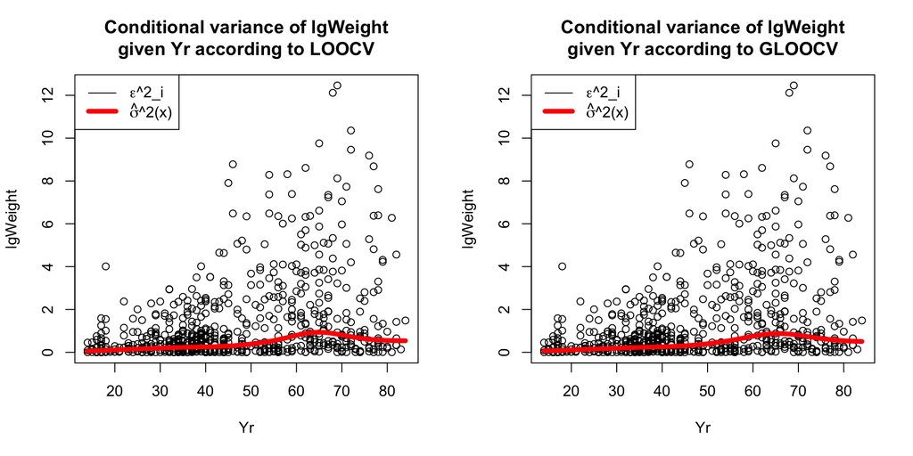

```r
s2.cv <- exp(q.cv)
s2.gcv <- exp(q.gcv)
par(mfrow = c(1, 2))
plot(e.1^2 ~ x, main = "Conditional variance of lgWeight\ngiven Yr according to LOOCV", xlab = "Yr", ylab = "lgWeight")
lines(s2.cv ~ x, col = "red", lw = 5)
legend("topleft", c(TeX("\\epsilon^2_i"), TeX("\\hat{\\sigma}^2(x)")), col = c("black", "red"), lwd = c(1, 5))
plot(e.1^2 ~ x, main = "Conditional variance of lgWeight\ngiven Yr according to GLOOCV", xlab = "Yr", ylab = "lgWeight")
lines(s2.gcv ~ x, col = "red", lw = 5)
legend("topleft", c(TeX("\\epsilon^2_i"), TeX("\\hat{\\sigma}^2(x)")), col = c("black", "red"), lwd = c(1, 5))
```

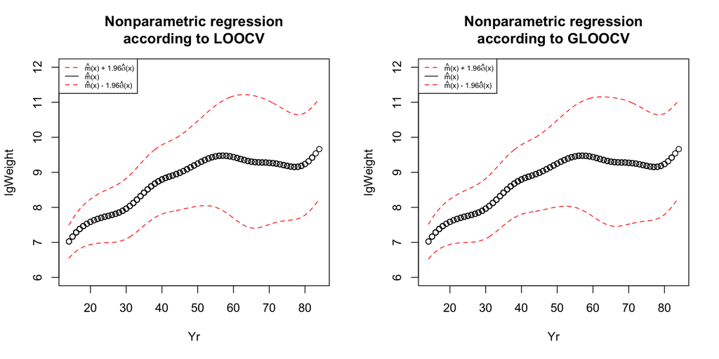

```r
s.cv <- sqrt(s2.cv)
s.gcv <- sqrt(s2.gcv)
par(mfrow = c(1, 2))
plot(m.1 ~ x,
  main = "Nonparametric regression\naccording to LOOCV", xlab = "Yr",
  ylab = "lgWeight", ylim=c(6,12)
)
lines(m.1 + 1.96 * s.cv ~ x, col="red", lty=2)
lines(m.1 - 1.96 * s.cv ~ x, col="red", lty=2)
legend("topleft", c(TeX("\\hat{m}(x) + 1.96\\hat{\\sigma}(x)"), TeX("\\hat{m}(x)"), TeX("\\hat{m}(x) - 1.96\\hat{\\sigma}(x)")), col = c("red", "black", "red"), lty=c(2,1,2),cex = 0.6)
plot(m.1 ~ x,
  main = "Nonparametric regression\naccording to GLOOCV", xlab = "Yr",
  ylab = "lgWeight", ylim=c(6,12)
)
lines(m.1 + 1.96 * s.gcv ~ x, col="red", lty=2)
lines(m.1 - 1.96 * s.gcv ~ x, col="red", lty=2)
legend("topleft", c(TeX("\\hat{m}(x) + 1.96\\hat{\\sigma}(x)"), TeX("\\hat{m}(x)"), TeX("\\hat{m}(x) - 1.96\\hat{\\sigma}(x)")), col = c("red", "black", "red"), lty=c(2,1,2),cex = 0.6)
```

Results are almost identical for both proposals of the bandwidth. We dedicide to keep the standard LOOCV as referential method

On the other hand, the estimation of the conditional variance fits visually the majority of the data, although there is a lot of dispersion in the errors between years 45 and 80 caused by many outliers. This makes the variance increase during those years as well.

The regression of lgWeight given Yr shows an irregular increase between years 10 and 40 of the maximum take-off weight of airplanes. Between years 40 and 50, lgWeight grows slowlier with a larger variance. Then, between the 50s and the 80s there is a slow decrease with a very large variance. Finally, in the last ten years, a significantly large growth happens.

To conclude, the modelled condicional variance is not constant, which validates the decision of using and heteroscedastic regression model.

## Using sm.regression to fit nonparametric regressions

```r
library(sm)
library(KernSmooth)
```

We first select the $h$ value using the direct plug-in method. Then we use it to fit a local nonparametric regression of lgWeight given Yr.

```r
h.dpill <- dpill(x,y,gridsize=101,
                 range.x=range(x))
paste0("Bandwidth value using plug-in method: ",h.dpill)
```

```
## [1] "Bandwidth value using plug-in method: 5.43348082231841"
```

```r
m.2<- sm.regression(x,y,h= h.dpill,eval.points = x)$estimate
```

Now, with the errors ($\epsilon$) of the previous regression, we are able to fit a nonparametric regression to $log(\epsilon^2)$ given Yr to estimate $log(\sigma^2(x))$, where $\sigma^2(x)$ is an estimate of the conditional variance of lgWeight given Yr.

```r
e.2 <- y - m.2
z.2 <- log(e.2^2)
q.h.dpill <- dpill(x,z.2,gridsize=101,
                 range.x=range(x))
paste0("Bandwidth value using plug-in method for q: ",q.h.dpill)
```

```
## [1] "Bandwidth value using plug-in method for q: 3.8547668095944"
```

```r
q.dpill<- sm.regression(x,z.2,h= q.h.dpill, eval.points= x)$estimate
```

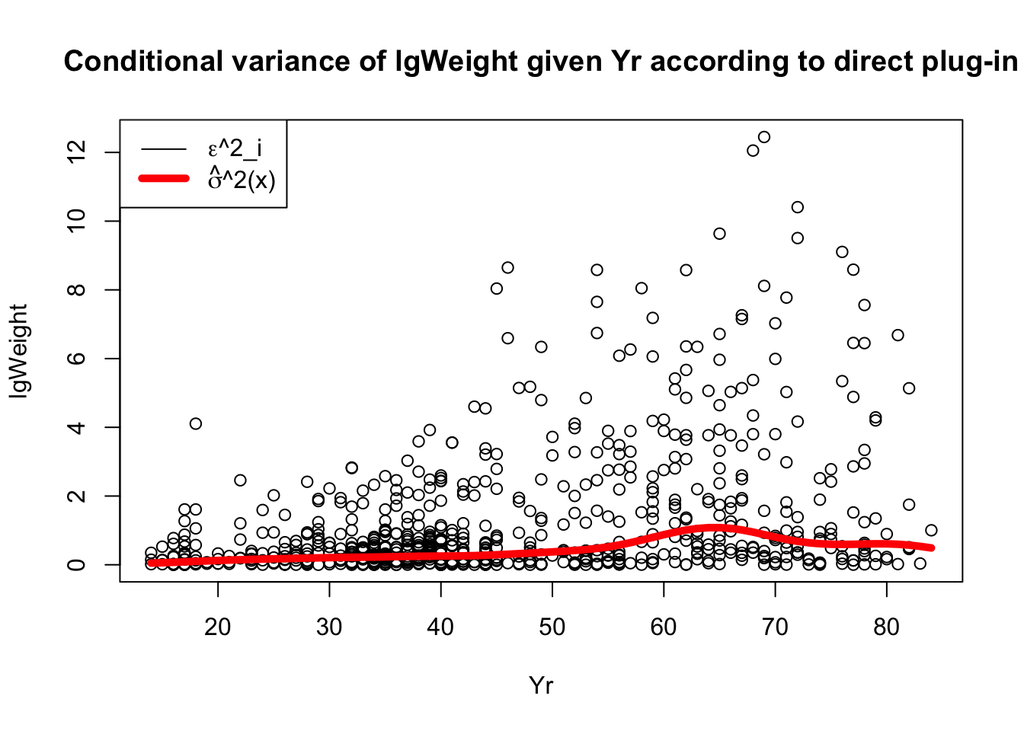

```r
s2.dpill <- exp(q.dpill)

plot(e.2^2 ~ x, main = "Conditional variance of lgWeight given Yr according to direct plug-in", xlab = "Yr", ylab = "lgWeight")
lines(s2.dpill ~ x, col = "red", lw = 5)
legend("topleft", c(TeX("\\epsilon^2_i"), TeX("\\hat{\\sigma}^2(x)")), col = c("black", "red"), lwd = c(1, 5))
```

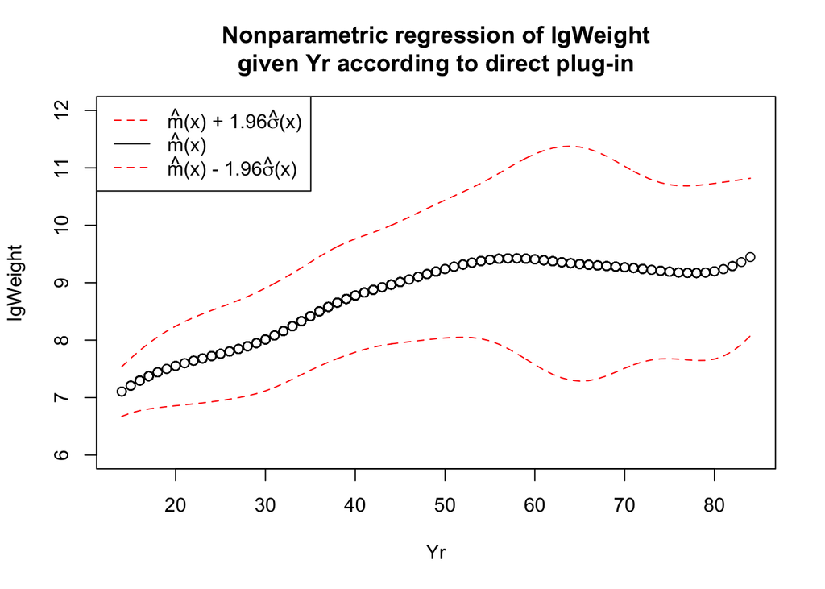

```r
s.dpill <- sqrt(s2.dpill)
plot(m.2 ~ x,
  main = "Nonparametric regression of lgWeight\ngiven Yr according to direct plug-in", xlab = "Yr",
  ylab = "lgWeight", ylim=c(6,12)
)
lines(m.2 + 1.96 * s.dpill ~ x, col="red", lty=2)
lines(m.2 - 1.96 * s.dpill ~ x, col="red", lty=2)
legend("topleft", c(TeX("\\hat{m}(x) + 1.96\\hat{\\sigma}(x)"), TeX("\\hat{m}(x)"), TeX("\\hat{m}(x) - 1.96\\hat{\\sigma}(x)")), col = c("red", "black", "red"), lty=c(2,1,2))
```

The increase in lgWeight appears smoother compared to the previous model. The variance remains relatively stable until until the 50s, where the model captures a slight decrease and an increase in variance. Toward the final years, a slightly growth in lgWeight is observed. Again, the modelled conditional variance is not constant, which validates the decision of using and heteroscedastic regression model as before.

## Comparison between LOOCV and direct plug-in method for choosing the bandwidth

```r
par(mfrow = c(1, 2))
paste0("h for m_hat using LOOCV: ",m.h.min.cv)
```

```
## [1] "h for m_hat using LOOCV: 4.18534611075141"
```

```r
paste0("h for m_hat using direct plug-in: ",h.dpill)
```

```
## [1] "h for m_hat using direct plug-in: 5.43348082231841"
```

```r
paste0("h for q_hat using LOOCV: ",q.h.min.cv)
```

```
## [1] "h for q_hat using LOOCV: 5.98491581336844"
```

```r
paste0("h for q_hat using direct plug-in: ",q.h.dpill)
```

```
## [1] "h for q_hat using direct plug-in: 3.8547668095944"
```

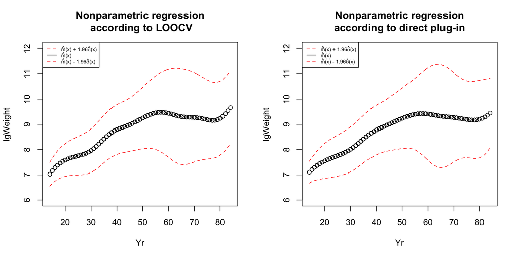

```r
plot(m.1 ~ x,
  main = "Nonparametric regression\n according to LOOCV", xlab = "Yr",
  ylab = "lgWeight", ylim=c(6,12)
)
lines(m.1 + 1.96 * s.cv ~ x, col="red", lty=2)
lines(m.1 - 1.96 * s.cv ~ x, col="red", lty=2)
legend("topleft", c(TeX("\\hat{m}(x) + 1.96\\hat{\\sigma}(x)"), TeX("\\hat{m}(x)"), TeX("\\hat{m}(x) - 1.96\\hat{\\sigma}(x)")), col = c("red", "black", "red"), lty=c(2,1,2),cex = 0.6)
plot(m.2 ~ x,
  main = "Nonparametric regression\naccording to direct plug-in", xlab = "Yr",
  ylab = "lgWeight", ylim=c(6,12)
)
lines(m.2 + 1.96 * s.dpill ~ x, col="red", lty=2)
lines(m.2 - 1.96 * s.dpill ~ x, col="red", lty=2)
legend("topleft", c(TeX("\\hat{m}(x) + 1.96\\hat{\\sigma}(x)"), TeX("\\hat{m}(x)"), TeX("\\hat{m}(x) - 1.96\\hat{\\sigma}(x)")), col = c("red", "black", "red"), lty=c(2,1,2),cex = 0.6)
```

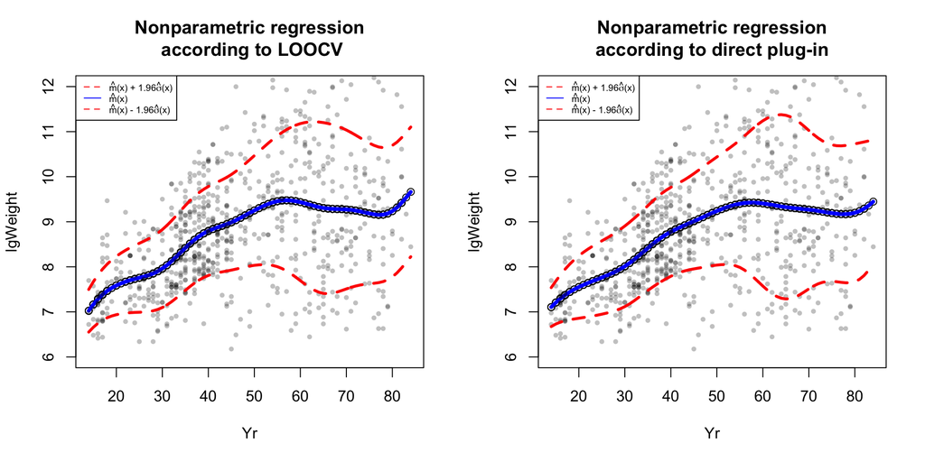

```r
plot(m.1 ~ x,
  main = "Nonparametric regression\n according to LOOCV", xlab = "Yr",
  ylab = "lgWeight", ylim=c(6,12)
)
lines(m.1 ~ x, col = "blue",lw = 4)
points(x, y, col = rgb(0, 0, 0, alpha = 0.25), pch = 16,cex = 0.7)
lines(m.1 + 1.96 * s.cv ~ x, col="red", lty=2,lw = 3)
lines(m.1 - 1.96 * s.cv ~ x, col="red", lty=2,lw = 3)
legend("topleft", c(TeX("\\hat{m}(x) + 1.96\\hat{\\sigma}(x)"), TeX("\\hat{m}(x)"), TeX("\\hat{m}(x) - 1.96\\hat{\\sigma}(x)")), col = c("red", "blue", "red"), lty=c(2,1,2),cex = 0.6)
plot(m.2 ~ x,
  main = "Nonparametric regression\naccording to direct plug-in", xlab = "Yr",
  ylab = "lgWeight", ylim=c(6,12)
)
lines(m.2 ~ x, col = "blue",lw = 4)
points(x, y, col = rgb(0, 0, 0, alpha = 0.25), pch = 16,cex = 0.7)
lines(m.2 + 1.96 * s.dpill ~ x, col="red", lty=2,lw = 3)
lines(m.2 - 1.96 * s.dpill ~ x, col="red", lty=2,lw = 3)
legend("topleft", c(TeX("\\hat{m}(x) + 1.96\\hat{\\sigma}(x)"), TeX("\\hat{m}(x)"), TeX("\\hat{m}(x) - 1.96\\hat{\\sigma}(x)")), col = c("red", "blue", "red"), lty=c(2,1,2),cex = 0.6)
```

From the results, we observe that LOOCV tends to select a smaller bandwidth for the estimation of $m(x)$, while the direct plug-in method chooses a larger bandwidth. The smaller bandwidth selected by LOOCV allows the estimate of $m(x)$ to follow the data more closely, capturing local patterns, whereas the larger bandwidth chosen by the Plug-In method results in a smoother estimate that may underfit the data.

Conversely, for the estimation of $q(x)$, LOOCV selects a larger bandwidth, while the direct plug-in method opts for a smaller one. This suggests that the direct plug-in method is more sensitive to noise in the variance, while LOOCV smooths out the variance, focusing on broader trends.

In a real case scenario, we would ask the data owners, who have field expertise, what would be more convenient to estimate lgWeight given Yr: a flatter variance as in the LOOCV case or a flatter $m(x)$ as when using direct plug-in. This way we would make sure to take the best possible decision.